# SAT Weather

```r
library("lubridate")
library("here")
library("tidyverse")
library("janitor")
library("colorspace")

theme_set(theme_minimal())
```

Data source: https://www.ncdc.noaa.gov/cdo-web/search?datasetid=GHCND (search for station ID `USW00012921`).

#### Step 1: Read the data

```r
satw <- here("12_data-manip2.5", "sat_weather.csv") %>%
  read_csv()

knitr::kable(head(satw))
```

| STATION | NAME | DATE | PRCP | SNOW | SNWD | TAVG | TMAX | TMIN |
| --- | --- | --- | --- | --- | --- | --- | --- | --- |
| USW00012921 | SAN ANTONIO INTERNATIONAL AIRPORT, TX US | 1946-08-14 | NA | NA | NA | 86 | NA | NA |
| USW00012921 | SAN ANTONIO INTERNATIONAL AIRPORT, TX US | 1946-08-15 | NA | NA | NA | 85 | NA | NA |
| USW00012921 | SAN ANTONIO INTERNATIONAL AIRPORT, TX US | 1946-08-16 | NA | NA | NA | 86 | NA | NA |
| USW00012921 | SAN ANTONIO INTERNATIONAL AIRPORT, TX US | 1946-08-17 | NA | NA | NA | 86 | NA | NA |
| USW00012921 | SAN ANTONIO INTERNATIONAL AIRPORT, TX US | 1946-08-18 | NA | NA | NA | 86 | NA | NA |
| USW00012921 | SAN ANTONIO INTERNATIONAL AIRPORT, TX US | 1946-08-19 | NA | NA | NA | 86 | NA | NA |

```r
summary(satw)
```

```
##    STATION              NAME                DATE
##  Length:26541       Length:26541       Min.   :1946-08-14
##  Class :character   Class :character   1st Qu.:1964-10-13
##  Mode  :character   Mode  :character   Median :1982-12-13
##                                        Mean   :1982-12-13
##                                        3rd Qu.:2001-02-11
##                                        Max.   :2019-04-13
##
##       PRCP               SNOW              SNWD             TAVG
##  Min.   : 0.00000   Min.   : 0.0000   Min.   :0.0000   Min.   :29.00
##  1st Qu.: 0.00000   1st Qu.: 0.0000   1st Qu.:0.0000   1st Qu.:60.00
##  Median : 0.00000   Median : 0.0000   Median :0.0000   Median :73.00
##  Mean   : 0.08457   Mean   : 0.0015   Mean   :0.0017   Mean   :70.17
##  3rd Qu.: 0.00000   3rd Qu.: 0.0000   3rd Qu.:0.0000   3rd Qu.:82.00
##  Max.   :11.26000   Max.   :13.2000   Max.   :9.0000   Max.   :94.00
##  NA's   :18         NA's   :1430      NA's   :1433     NA's   :21645
##       TMAX             TMIN
##  Min.   : 23.00   Min.   : 0.00
##  1st Qu.: 71.00   1st Qu.:46.00
##  Median : 82.00   Median :62.00
##  Mean   : 80.12   Mean   :58.44
##  3rd Qu.: 92.00   3rd Qu.:72.00
##  Max.   :111.00   Max.   :82.00
##  NA's   :18       NA's   :18
```

Some issues:

- There are TMAX and TMIN measurements on almost every day (18 missing values), but many TAVG measurements are missing.
- The column names and ALL CAPS text values are annoying

#### Step 2: clean the names/text

```r
satw <- satw %>%
  clean_names() %>%
  mutate_if(is.character, tolower)

knitr::kable(head(satw))
```

| station | name | date | prcp | snow | snwd | tavg | tmax | tmin |
| --- | --- | --- | --- | --- | --- | --- | --- | --- |
| usw00012921 | san antonio international airport, tx us | 1946-08-14 | NA | NA | NA | 86 | NA | NA |
| usw00012921 | san antonio international airport, tx us | 1946-08-15 | NA | NA | NA | 85 | NA | NA |
| usw00012921 | san antonio international airport, tx us | 1946-08-16 | NA | NA | NA | 86 | NA | NA |
| usw00012921 | san antonio international airport, tx us | 1946-08-17 | NA | NA | NA | 86 | NA | NA |
| usw00012921 | san antonio international airport, tx us | 1946-08-18 | NA | NA | NA | 86 | NA | NA |
| usw00012921 | san antonio international airport, tx us | 1946-08-19 | NA | NA | NA | 86 | NA | NA |

#### Step 3: Create year and month columns

```r
satw <- satw %>%
  mutate(year = year(date),
         month = factor(month(date), labels = month.abb)) %>%
  select(year, month, date, starts_with("t"))

knitr::kable(head(satw))
```

| year | month | date | tavg | tmax | tmin |
| --- | --- | --- | --- | --- | --- |
| 1946 | Aug | 1946-08-14 | 86 | NA | NA |
| 1946 | Aug | 1946-08-15 | 85 | NA | NA |
| 1946 | Aug | 1946-08-16 | 86 | NA | NA |
| 1946 | Aug | 1946-08-17 | 86 | NA | NA |
| 1946 | Aug | 1946-08-18 | 86 | NA | NA |
| 1946 | Aug | 1946-08-19 | 86 | NA | NA |

#### Step 4: deal with missing tavg

Problem: some rows have `tmax` and `tmin` but are missing `tavg`, while a few rows have `tavg` but no `tmax` or `tmin`.

We cannot recover `tmax` and `tmin` when they are missing, but we can approximate any missing `tavg` values by taking the average of `tmax` and `tmin` for that day.

Then we need to “coalesce” the two different kinds of `tavg` measurements: use the recorded tavg if present, otherwise use the approximated one.

There’s a nice function called `coalesce()` that will accomplish this for us. Given a set of vectors, it takes the first non-missing value at each position. For example

```
y <- c(1, 2, NA, NA, 5)
z <- c(NA, NA, 3, 4, 5)
coalesce(y, z)

[1] 1 2 3 4 5
```

Create a new variable `tavg_approx` that is the average of tmax and tmin, then coalesce `tavg` with `tavg_approx`.

```r
satw <- satw %>%
  mutate(tavg_approx = (tmax + tmin) / 2,
         tavg = coalesce(tavg, tavg_approx)) %>%  # Measured tavg first
  select(-tavg_approx)

knitr::kable(head(satw))
```

| year | month | date | tavg | tmax | tmin |
| --- | --- | --- | --- | --- | --- |
| 1946 | Aug | 1946-08-14 | 86 | NA | NA |
| 1946 | Aug | 1946-08-15 | 85 | NA | NA |
| 1946 | Aug | 1946-08-16 | 86 | NA | NA |
| 1946 | Aug | 1946-08-17 | 86 | NA | NA |
| 1946 | Aug | 1946-08-18 | 86 | NA | NA |
| 1946 | Aug | 1946-08-19 | 86 | NA | NA |

#### Step 5: monthly summary

Create a summary data set that is the mean of each `t` variable for each year and month.

```r
satw_monthly <- satw %>%
  group_by(year, month) %>%
  summarise_at(vars(starts_with("t")), mean, na.rm = TRUE)

knitr::kable(head(satw_monthly))
```

| year | month | tavg | tmax | tmin |
| --- | --- | --- | --- | --- |
| 1946 | Aug | 82.05556 | NaN | NaN |
| 1946 | Sep | 78.11667 | 86.16667 | 70.06667 |
| 1946 | Oct | 72.38710 | 81.41935 | 63.35484 |
| 1946 | Nov | 60.43333 | 70.13333 | 50.73333 |
| 1946 | Dec | 55.80645 | 67.16129 | 44.45161 |
| 1947 | Jan | 48.45161 | 58.16129 | 38.74194 |

#### Step 6: pivot to longer format

For plotting, we will want to facet by the kind of temperature measurement (`tmin`, `tavg`, or `tmax`). That means we will need our data in “long” format with the variable names in a single new column and all the values in another new column.

After doing this, you can also reorder the new variable column so that the variables are plotted with `tmin` first and `tmax` last rather than alphabetically. Hint: mutate your new variable column using `fct_reorder()`, and reorder by the new value column. See [this section of R4DS](https://r4ds.had.co.nz/factors.html#modifying-factor-order) for an example.

```r
satw_long <- satw_monthly %>%
  pivot_longer(cols = starts_with("t"), names_to = "variable", values_to = "value")

# Reorder variables from smallest to largest
satw_long <- satw_long %>%
  mutate(variable = fct_reorder(variable, value, .fun = mean, na.rm = TRUE))

knitr::kable(head(satw_long))
```

| year | month | variable | value |
| --- | --- | --- | --- |
| 1946 | Aug | tavg | 82.05556 |
| 1946 | Aug | tmax | NaN |
| 1946 | Aug | tmin | NaN |
| 1946 | Sep | tavg | 78.11667 |
| 1946 | Sep | tmax | 86.16667 |
| 1946 | Sep | tmin | 70.06667 |

#### Step 7: tile plot of actual values

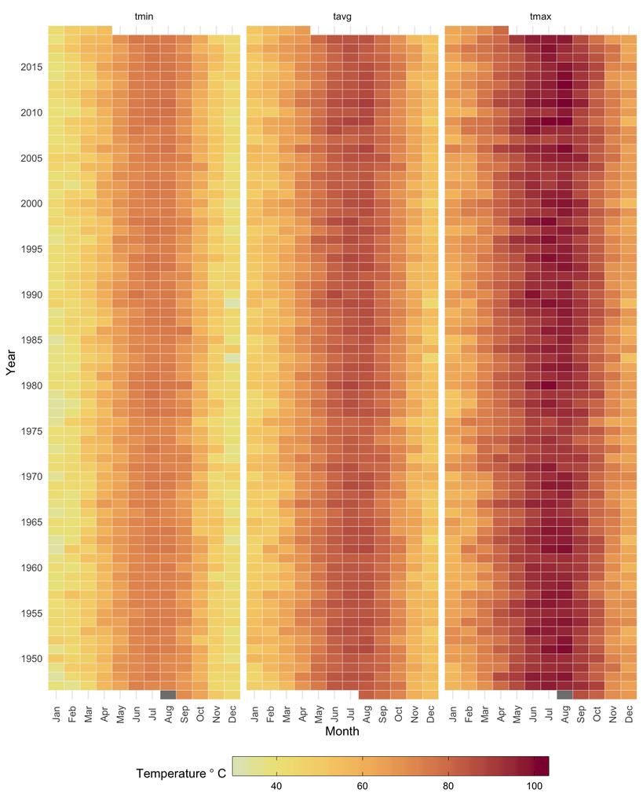

```r
ggplot(satw_long, aes(x = month, y = year, fill = value)) +
  geom_tile(color = "white") +
  scale_fill_continuous_sequential("Heat", name = expression(Temperature~degree~C)) +
  facet_wrap(~variable) +
  scale_y_continuous(breaks = seq(1950, 2020, by = 5)) +
  coord_cartesian(expand = FALSE) +
  labs(x = "Month", y = "Year") +
  guides(fill = guide_colorbar(frame.colour = "black", ticks.colour = "black")) +
  theme(legend.position = "bottom",
        axis.text.x = element_text(angle = 90, vjust = 0.5),
        legend.key.width = unit(2, "cm"))
```

Yep… looks about right. Pretty hot in the summer.

#### Step 8: calculate the temperature anomaly for each month and variable using a grouped mutate

```r
satw_anom <- satw_long %>%
  group_by(month, variable) %>%
  mutate(anom = value - mean(value, na.rm = TRUE)) %>%
  ungroup()

knitr::kable(head(satw_anom))
```

| year | month | variable | value | anom |
| --- | --- | --- | --- | --- |
| 1946 | Aug | tavg | 82.05556 | -2.7803800 |
| 1946 | Aug | tmax | NaN | NaN |
| 1946 | Aug | tmin | NaN | NaN |
| 1946 | Sep | tavg | 78.11667 | -1.5607306 |
| 1946 | Sep | tmax | 86.16667 | -3.9054795 |
| 1946 | Sep | tmin | 70.06667 | 0.6273973 |

#### Step 9: tile plot of temperature anomalies

To get the diverging color scale right (centered at zero), find the largest absolute value in the new anomaly column, e.g.,

`lim <- max(abs(satw_anom$anom), na.rm = TRUE)`

Then use `limits = c(-lim, lim)` in your `scale_fill_` function.

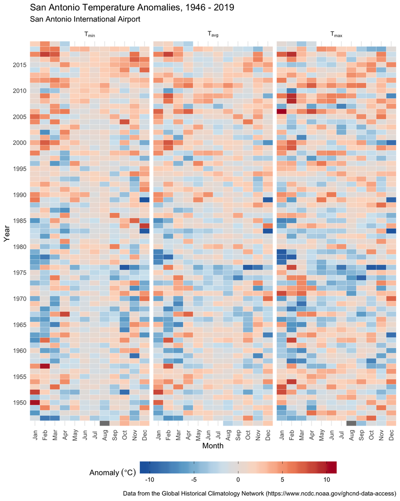

```r
satw_anom <- satw_anom %>%
  mutate(variable = fct_recode(variable, "T[min]" = "tmin", "T[avg]" = "tavg", "T[max]" = "tmax"))

# Find largest absolute anomaly so that we can center the color scale on zero
lim <- max(abs(satw_anom$anom), na.rm = TRUE)

ggplot(satw_anom, aes(x = month, y = year, fill = anom)) +
  geom_tile(color = "white") +
  scale_fill_distiller(palette = "RdBu",
                       limits = c(-lim, lim), # Here we provide limits to center the color scale on zero
                       name = expression(Anomaly~(degree*C))) +
  facet_wrap(~variable, labeller = label_parsed) +
  scale_y_continuous(breaks = seq(1950, 2020, by = 5)) +
  coord_cartesian(expand = FALSE) +
  guides(fill = guide_colorbar(ticks.colour = "black")) +
  labs(x = "Month", y = "Year",
       title = "San Antonio Temperature Anomalies, 1946 - 2019",
       subtitle = "San Antonio International Airport",
       caption = "Data from the Global Historical Climatology Network (https://www.ncdc.noaa.gov/ghcnd-data-access)") +
  theme(legend.position = "bottom",
        axis.text.x = element_text(angle = 90, vjust = 0.5),
        legend.key.width = unit(2, "cm"))
```